# Soil Color Contrast

## 2.3 Color Contrast Charts

Inspect the data used to generate the figures with the additional argument `returnData=TRUE`.

Basic chart, single reference hue.

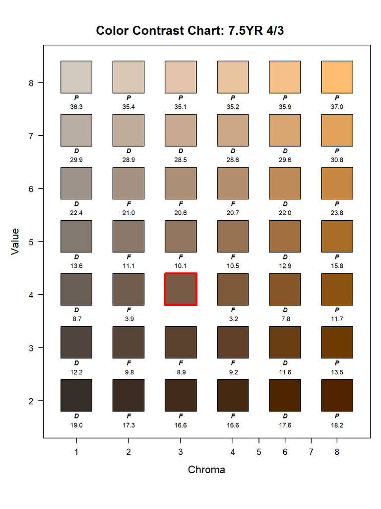

```r
contrastChart(m = '7.5YR 4/3', hues = c('7.5YR'))
```

Threshold color chips by $\Delta{E_{00}}$.

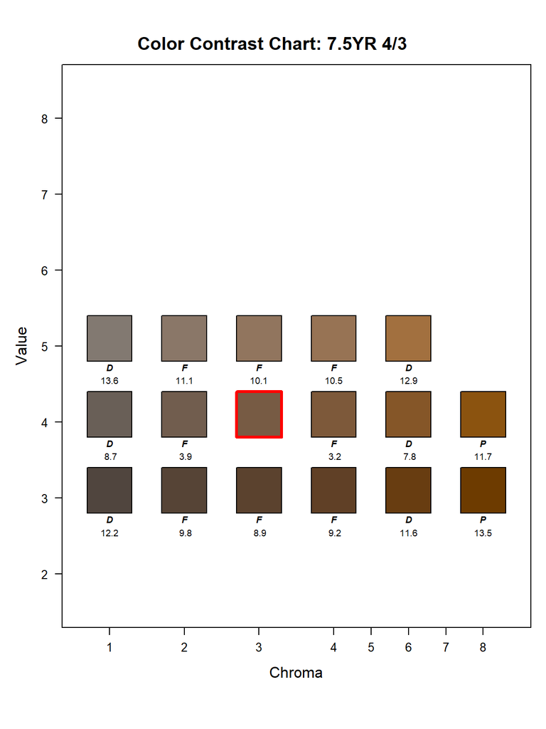

```r
contrastChart(m = '7.5YR 4/3', hues = c('7.5YR'), thresh = 15)
```

Multiple reference hues.

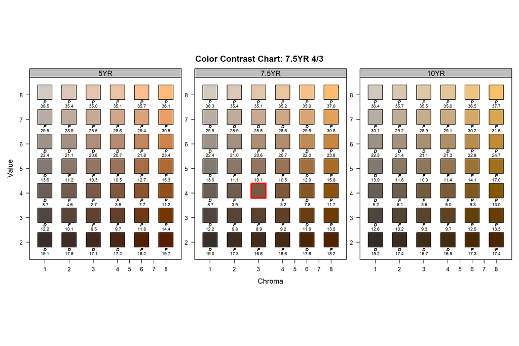

```r
contrastChart(m = '7.5YR 4/3', hues = c('5YR', '7.5YR', '10YR'))
```

Split chips by contrast class, single reference hue.

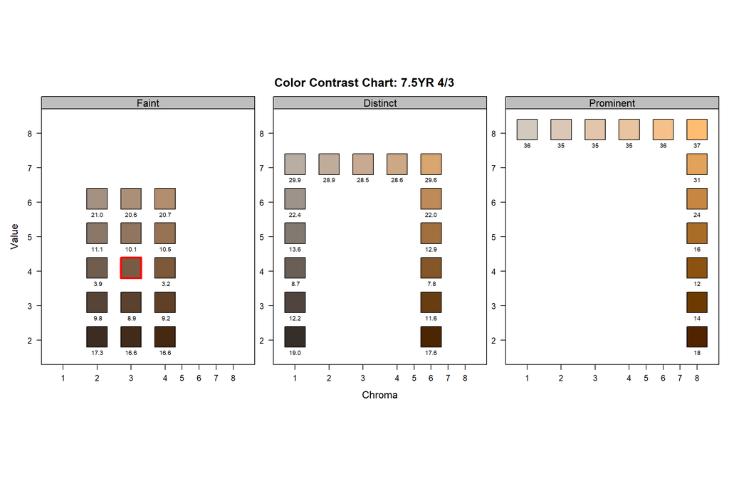

```r
contrastChart(m = '7.5YR 4/3', hues = c('7.5YR'), style = 'CC')
```

Split chips by contrast class, multiple reference hues. This works better when run through `latticeExtra::useOuterStrips()`.

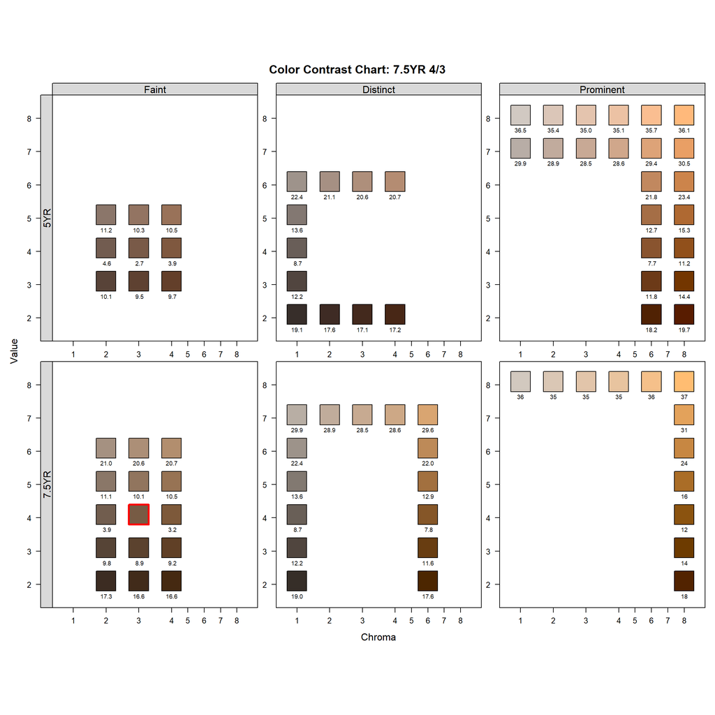

```r
fig <- contrastChart(m = '7.5YR 4/3', hues = c('5YR', '7.5YR'), style = 'CC')
useOuterStrips(fig, strip = strip.custom(bg=grey(0.85)), strip.left = strip.custom(bg=grey(0.85)) )
```

## 2.4 Example 1

```r
# load full LUT from {aqp}
data(munsell)

# subset some common colors
hues <- c('10R', '2.5YR', '5YR', '7.5YR', '10YR', '2.5Y', '5Y')
x <- subset(munsell, subset=value %in% 3:5 & chroma %in% 1:3 & hue %in% hues)

# convert into an ordered factor, according to hue position
huePos <- huePosition(x=NULL, returnHues = TRUE)
x$hue <- factor(x$hue, levels=huePos, ordered = TRUE)
x$hue <- droplevels(x$hue)


# ok
table(x$hue)
```

```
##
##   10R 2.5YR   5YR 7.5YR  10YR  2.5Y    5Y
##     9     9     9     9     9     9     9
```

```r
nrow(x)
```

```
## [1] 63
```

```r
# convert into hex notation for plotting
x$color <- munsell2rgb(x$hue, x$value, x$chroma)
x$munsell <- sprintf("%s %s/%s", x$hue, x$value, x$chroma)
```

Arrange colors in a familiar manner.

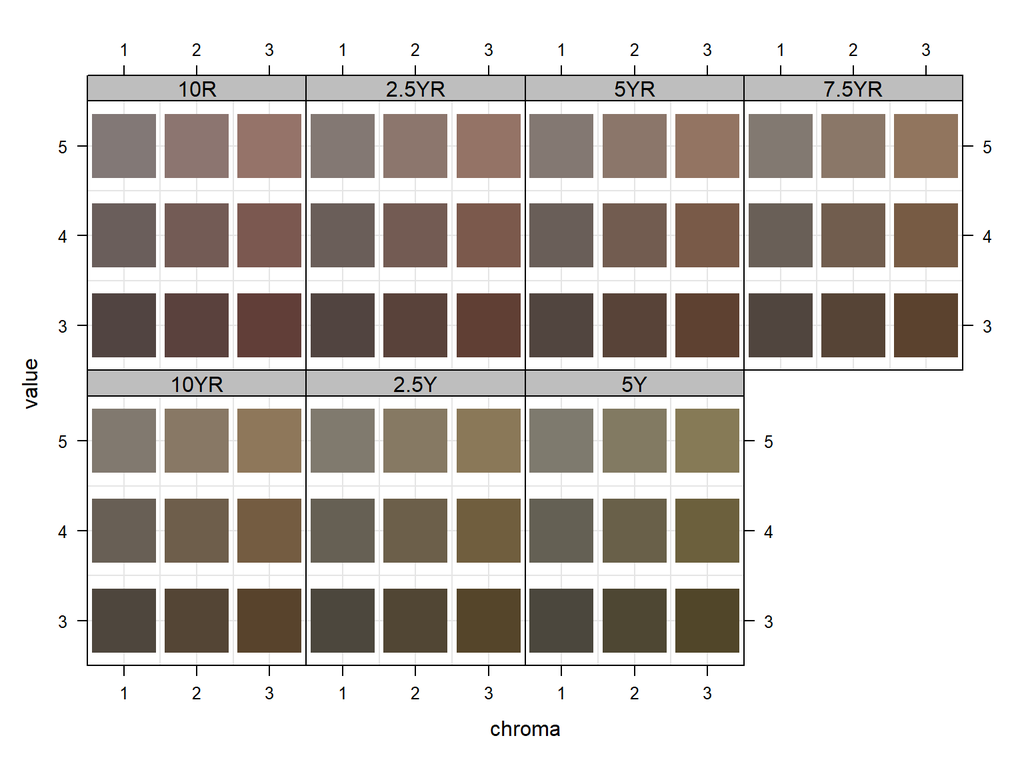

```r
xyplot(value ~ chroma | hue, data=x,
       xlim=c(0.5, 3.5), ylim=c(2.5, 5.5),
       scales=list(alternating=3, x=list(at=1:3), y=list(at=3:5)),
       as.table=TRUE, strip=strip.custom(bg='grey'),
       subscripts=TRUE,
       panel=function(xx, yy, subscripts, ...) {
         panel.grid(-1, -1)
         panel.points(xx, yy, col=x$color[subscripts], pch=15, cex=6)
       }
)
```

Evaluate $\Delta~E_{00}$ via `{farver}` pacakge.

```r
# dE00
# pair-wise distances are only present in the upper triangle
# lower triangle is 0
d <- compare_colour(x[, c('L', 'A', 'B')], from_space='lab', white_from = 'D65', method='cie2000')
# copy color codes for convenience
dimnames(d) <- list(x$munsell, x$munsell)

# convert to dist object, which expects distances in the lower triangle
d.dist <- as.dist(t(d))
# hierarchical clustering
h <- as.phylo(as.hclust(diana(d.dist)))
# nMDS
mds <- MASS::sammon(d.dist, trace = FALSE)
```

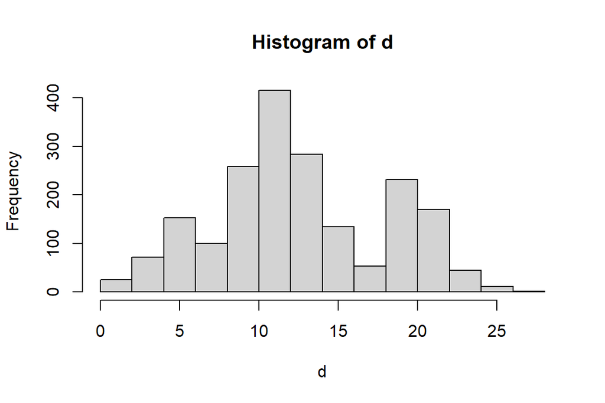

```r
# remove 0's in lower triangle and diagonal
d[lower.tri(d, diag = TRUE)] <- NA
hist(d)
```

```r
# double-check that ordering is correct
# yes
table(h$tip.label == x$munsell)
```

```
##
## TRUE
##   63
```

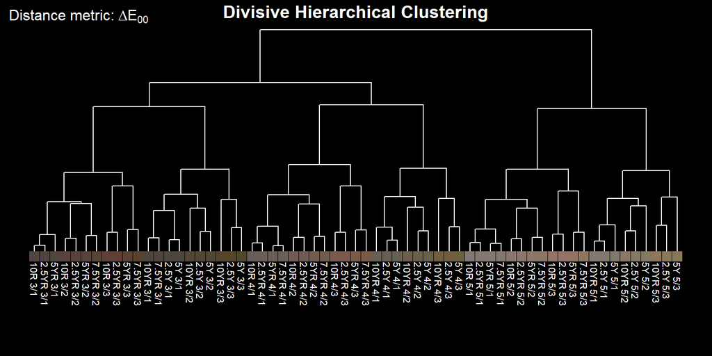

```r
par(mar=c(0.5,0.5,1,0.5), bg='black', fg='white')

plot(h, label.offset=0.55, edge.color='white', tip.color='white', cex=0.66, direction='downwards', font=1)
tiplabels(pch=15, cex=1.5, col=x$color, offset=0.23)
title('Divisive Hierarchical Clustering', col.main='white', line=0)
mtext(text = expression("Distance metric:"~Delta*E['00']), side = 3, adj = 0, line=-0.5)
```

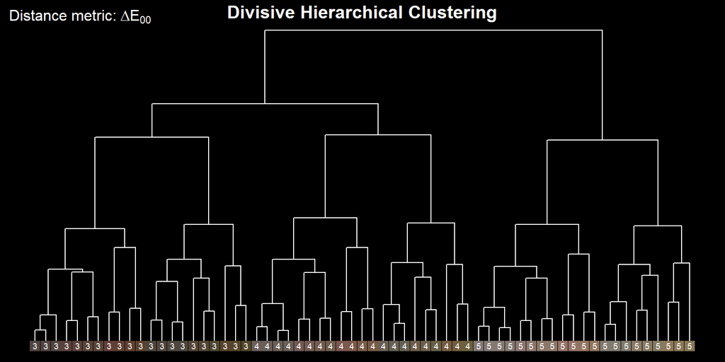

```r
plot(h, edge.color='white', tip.color='white', cex=0.5, direction='downwards', show.tip.label=FALSE)
tiplabels(pch=15, cex=1.5, col=x$color, offset=0.25)
tiplabels(text=x$value, cex=0.55, frame='none', col='white', offset=0.23)
title('Divisive Hierarchical Clustering', col.main='white', line=0)
mtext(text = expression("Distance metric:"~Delta*E['00']), side = 3, adj = 0, line=-0.5)
```

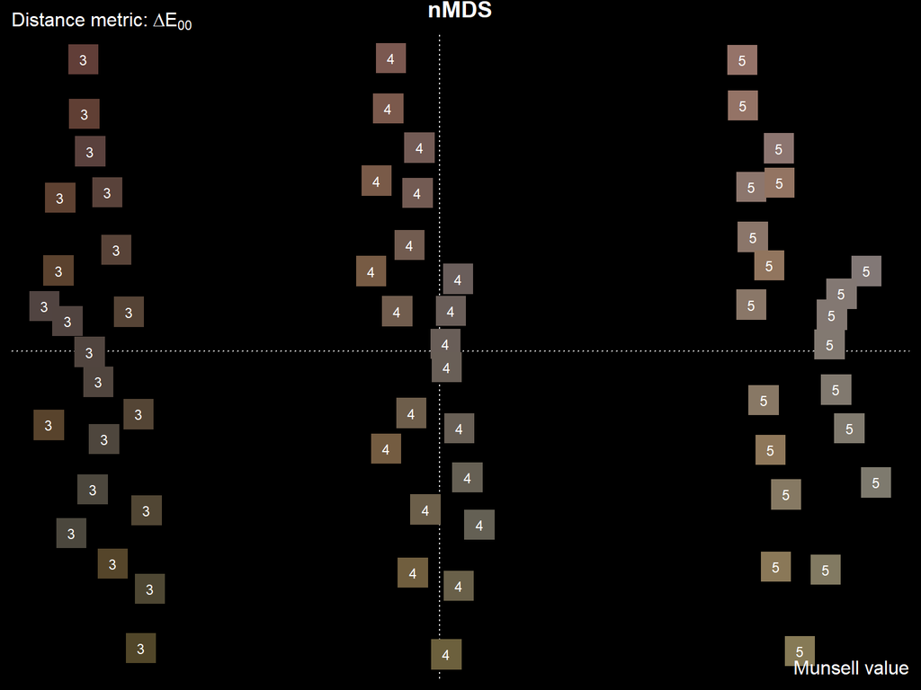

```r
par(mar=c(0.5,0.5,1.5,0.5), bg='black', fg='white')

plot(mds$points, type='n', axes=FALSE)
abline(h=0, v=0, col=grey(0.85), lty=3)
points(mds$points, pch=15, col=x$color, cex=3.5)
text(mds$points[, 1],  mds$points[, 2], x$value, cex=0.75)
mtext(text = expression("Distance metric:"~Delta*E['00']), side = 3, adj = 0)
mtext(text = 'Munsell value', side = 1, adj = 1, line=-1)
title('nMDS', col.main='white', line=0.75)
```

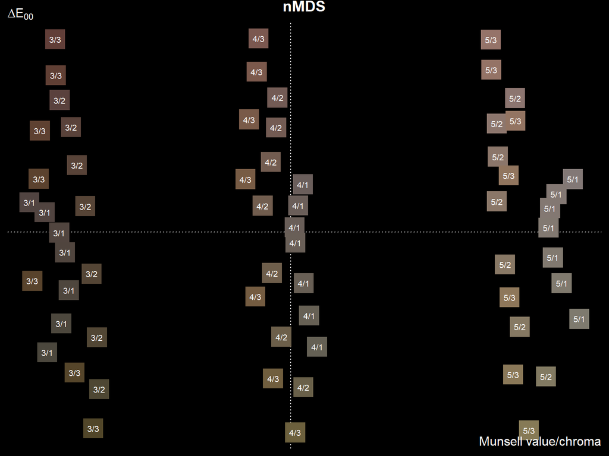

```r
plot(mds$points, type='n', axes=FALSE)
abline(h=0, v=0, col=grey(0.85), lty=3)
points(mds$points, pch=15, col=x$color, cex=3.5)
text(mds$points[, 1],  mds$points[, 2], paste0(x$value, '/', x$chroma), cex=0.66)
mtext(text = expression(Delta*E['00']), side = 3, adj = 0)
mtext(text = 'Munsell value/chroma', side = 1, adj = 1, line=-1)
title('nMDS', col.main='white', line=0.75)
```

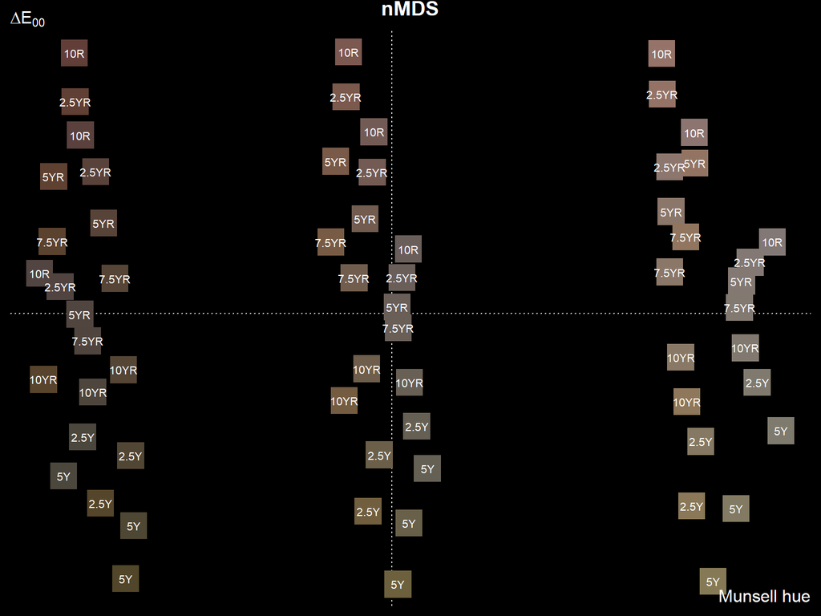

```r
plot(mds$points, type='n', axes=FALSE)
abline(h=0, v=0, col=grey(0.85), lty=3)
points(mds$points, pch=15, col=x$color, cex=3.5)
text(mds$points[, 1],  mds$points[, 2], x$hue, cex=0.66)
mtext(text = expression(Delta*E['00']), side = 3, adj = 0)
mtext(text = 'Munsell hue', side = 1, adj = 1, line=-1)
title('nMDS', col.main='white', line=0.75)
```

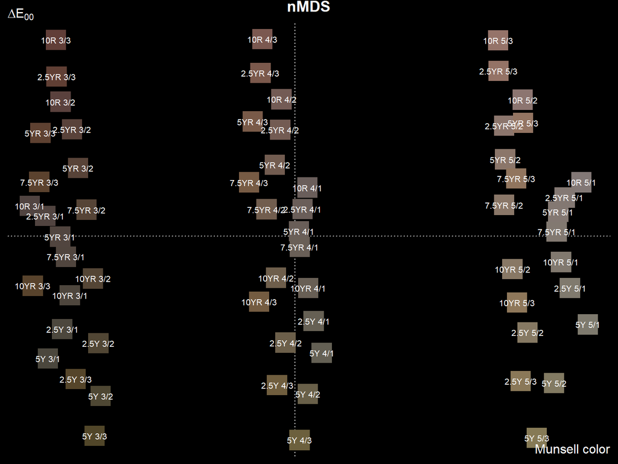

```r
plot(mds$points, type='n', axes=FALSE)
abline(h=0, v=0, col=grey(0.85), lty=3)
points(mds$points, pch=15, col=x$color, cex=3.5)
text(mds$points[, 1],  mds$points[, 2], x$munsell, cex=0.66)
mtext(text = expression(Delta*E['00']), side = 3, adj = 0)
mtext(text = 'Munsell color', side = 1, adj = 1, line=-1)
title('nMDS', col.main='white', line=0.75)
```

## 2.5 Color Chips Arranged by Perceptual Differences

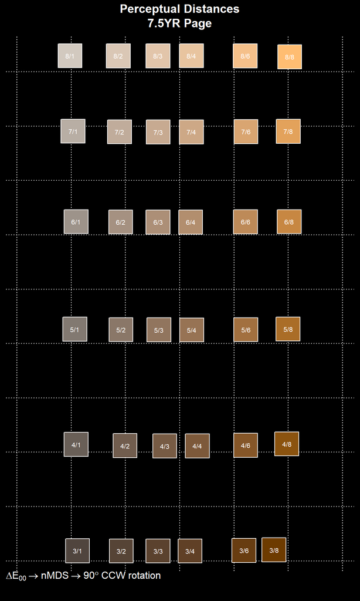

```r
# subset some common colors
hues <- c('7.5YR')
x <- subset(munsell, subset=value %in% 3:8 & chroma %in% c(1,2,3,4,6,8) & hue %in% hues)

# convert into hex notation for plotting
x$color <- munsell2rgb(x$hue, x$value, x$chroma)
x$munsell <- sprintf("%s/%s", x$value, x$chroma)

# dE00
# pair-wise distances are only present in the upper triangle
# lower triangle is 0
d <- compare_colour(x[, c('L', 'A', 'B')], from_space='lab', white_from = 'D65', method = 'cie2000')

# copy color codes for convenience
dimnames(d) <- list(x$munsell, x$munsell)

# convert to dist object, which expects distances in the lower triangle
d.dist <- as.dist(t(d))

# nMDS
mds <- MASS::sammon(d.dist, trace = FALSE)

# rotate 90 degrees CCW
# to roughly follow Munsell color book page layout
# column-order
m <- matrix(
  c(0, -1,
    1, 0),
  byrow = FALSE, ncol = 2
)

# apply transformation
mds.trans <- mds$points %*% m

par(mar=c(2.5, 0.5, 3, 0.5), bg='black', fg='white')

plot(mds.trans, type='n', axes=FALSE, asp=1)
abline(h=seq(-25, 25, 5), v=seq(-25, 25, 5), col='white', lty=3)
points(mds.trans, pch=22, bg=x$color, cex=6)
text(mds.trans[, 1],  mds.trans[, 2], paste0(x$value, '/', x$chroma), cex=0.66)
# mtext(text = expression(Delta*E['00']), side = 3, adj = 0)
# mtext(text = '7.5YR', side = 1, adj = 1, line=-1)
title('Perceptual Distances\n7.5YR Page', col.main='white', line=0.75)
mtext(text = expression(Delta*E['00']%->%nMDS%->%90*degree~CCW~rotation), side = 1, adj = 0)
```

Map perceptual arrangement to original representation in color book.

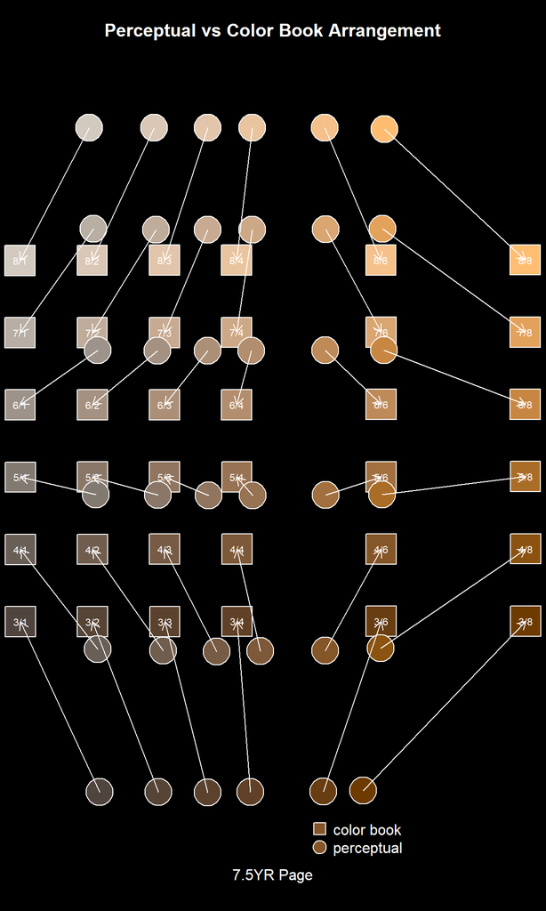

```r
p <- procrustes(mds.trans, x[, c('value', 'chroma')], scale = TRUE, symmetric = TRUE)

par(mar=c(2.5, 0, 3, 0), bg='black', fg='white')

plot(p, pch=22, kind=0, axes=FALSE, xlab='', ylab='')
points(p, display='rotated', pch=22, bg=x$color, cex=5)
points(p, display='target', pch=21, bg=x$color, cex=4)
lines(p, type='arrows', length=0.1)
text(p, display='rotated', cex=0.66, labels=paste0(x$value, '/', x$chroma))
title('Perceptual vs Color Book Arrangement', col.main='white', line=1)
title(sub='7.5YR Page', col.sub='white', line=0)
legend('bottomright', legend=c('color book', 'perceptual'), pch=c(22, 21), pt.bg=parseMunsell('7.5YR 4/6'), pt.cex=2, bty='n', inset=c(0.25, 0))
```

## 2.6 Moist vs. Dry Colors

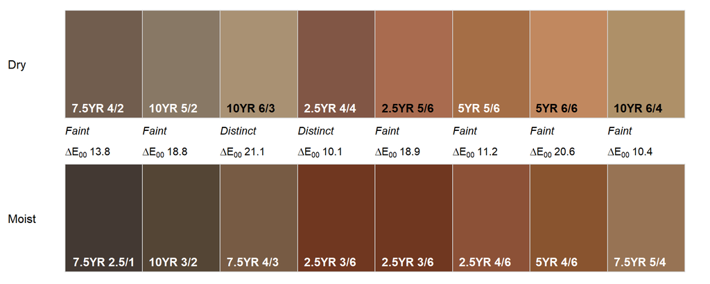

```r
x <- fetchOSD('musick', colorState = 'dry')
y <- fetchOSD('musick', colorState = 'moist')

m1 <- sprintf("%s %s/%s", x$hue, x$value, x$chroma)
m2 <- sprintf("%s %s/%s", y$hue, y$value, y$chroma)

cc <- colorContrast(m1, m2)

colorContrastPlot(m1, m2, labels=c('Dry', 'Moist'), d.cex = 0.9)
```

Tinker with plot settings and optimize for dark background.

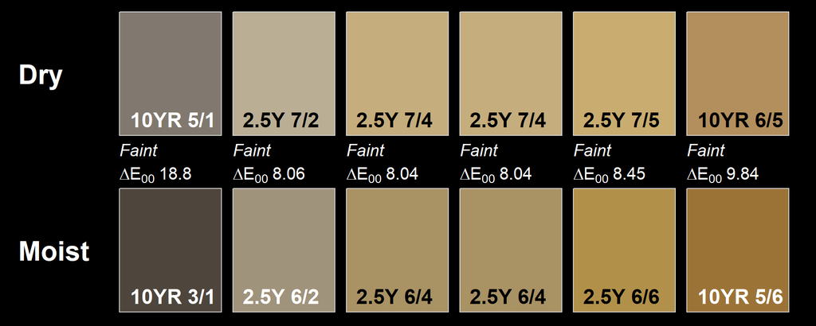

```r
x <- fetchOSD('Leefield', colorState = 'dry')
y <- fetchOSD('Leefield', colorState = 'moist')

m1 <- sprintf("%s %s/%s", x$hue, x$value, x$chroma)
m2 <- sprintf("%s %s/%s", y$hue, y$value, y$chroma)

par(bg='black', fg='white')
colorContrastPlot(m1, m2, labels=c('Dry', 'Moist'), printMetrics = TRUE, d.cex = 1.25, col.cex = 1.5, label.cex = 2, label.font = 2)
```

## 2.7 Differences Between Adjacent Chips

```r
# fresh start
data(munsell)

# for now, most commonly used hue pages, but expanded to full range in value / chroma
x <- subset(munsell, subset = hue %in% c('10R', '2.5YR', '5YR', '7.5YR', '10YR', '2.5Y', '5Y') & value %in% 2:8 & chroma %in% 2:8)

# create all pair-wise combinations
cols <- paste0(x$hue, ' ', x$value, '/', x$chroma)
z <- combn(cols, 2)

# convert to 2-column data.frame
# ~ 674,541 combinations!
z <- data.frame(t(z), stringsAsFactors = FALSE)

## TODO: make this a new function

# borrowed from aqp::colorContrast
m1.pieces <- parseMunsell(z[[1]], convertColors = FALSE)
m2.pieces <- parseMunsell(z[[2]], convertColors = FALSE)

# convert to value and chroma to numeric
m1.pieces[[2]] <- as.numeric(m1.pieces[[2]])
m1.pieces[[3]] <- as.numeric(m1.pieces[[3]])
m2.pieces[[2]] <- as.numeric(m2.pieces[[2]])
m2.pieces[[3]] <- as.numeric(m2.pieces[[3]])

# difference in number of hue chips, clock-wise, as specified in:
# https://www.nrcs.usda.gov/wps/portal/nrcs/detail/soils/ref/?cid=nrcs142p2_053569
dH <- abs(huePosition(m1.pieces[[1]]) - huePosition(m2.pieces[[1]]))
# difference in number of value chips
dV <- abs(m1.pieces[[2]] - m2.pieces[[2]])
# difference in number of chroma chips
dC <- abs(m1.pieces[[3]] - m2.pieces[[3]])

## ^^^^ need a new function

# just adjacent chips
# ~ 11,498 combinations
idx <- which(dH %in% c(0, 1) & dV %in% c(0, 1) & dC %in% c(0, 1))
z <- z[idx, ]

# compute color contrast metrics on adjacent chips
d <- colorContrast(z[[1]], z[[2]])

# summaries
quantile(d$dE00)
```

```
##         0%        25%        50%        75%       100%
##  0.5953389  4.5671749  8.5066099  9.7738249 12.6409729
```

```r
# encode combinations
d$code <- sprintf("%s-%s-%s", d$dH, d$dV, d$dC)

# compute select quantiles of dE00 by combination
adj <- lapply(split(d, d$code), function(i) {
  qq <- round(quantile(i$dE00, probs = c(0.05, 0.5, 0.95)))
  data.frame(
    dH = i$dH[1],
    dV = i$dV[1],
    dC = i$dC[1],
    q05 = qq[1],
    q50 = qq[2],
    q95 = qq[3]
  )

}
)

adj <- do.call('rbind', adj)

# all combinations
knitr::kable(adj)
```

|  | dH | dV | dC | q05 | q50 | q95 |
| --- | --- | --- | --- | --- | --- | --- |
| 0-0-1 | 0 | 0 | 1 | 1 | 3 | 4 |
| 0-1-0 | 0 | 1 | 0 | 7 | 9 | 10 |
| 0-1-1 | 0 | 1 | 1 | 7 | 9 | 11 |
| 1-0-0 | 1 | 0 | 0 | 2 | 4 | 5 |
| 1-0-1 | 1 | 0 | 1 | 4 | 5 | 6 |
| 1-1-0 | 1 | 1 | 0 | 8 | 9 | 11 |
| 1-1-1 | 1 | 1 | 1 | 8 | 10 | 11 |

```r
# just changes along a single dimension
idx <- which(row.names(adj) %in% c('1-0-0', '0-1-0', '0-0-1'))
knitr::kable(adj[idx[3:1], ])
```

|  | dH | dV | dC | q05 | q50 | q95 |
| --- | --- | --- | --- | --- | --- | --- |
| 1-0-0 | 1 | 0 | 0 | 2 | 4 | 5 |
| 0-1-0 | 0 | 1 | 0 | 7 | 9 | 10 |
| 0-0-1 | 0 | 0 | 1 | 1 | 3 | 4 |

## 2.8 dE00 Between Hues

Including N chip.

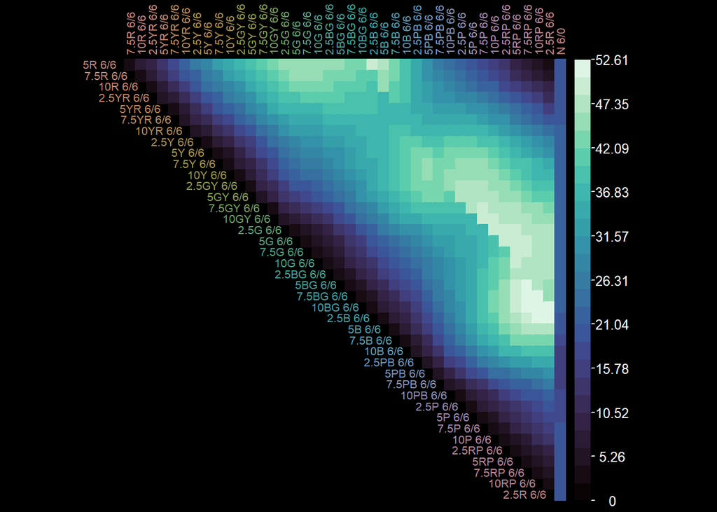

```r
library(corrplot)

# fresh start
data(munsell)

# for now, most commonly used hue pages, but expanded to full range in value / chroma
x1 <- subset(munsell, subset = value == 6 & chroma == 6)

# neutral
x2 <- subset(munsell, subset = hue == 'N' & value == 6 )

# combine
x <- rbind(x1, x2)

# re-arrange into "hue order"
idx <- match(huePosition(returnHues = TRUE, includeNeutral = TRUE), x$hue)
x <- x[idx, ]

x$m <- sprintf("%s %s/%s", x$hue, x$value, x$chroma)
x$col <- rgb(x$r, x$g, x$b, maxColorValue = 1)


d <- farver::compare_colour(
  from = x[, c('L', 'A', 'B')],
  to = x[, c('L', 'A', 'B')],
  from_space = 'lab',
  method = 'CIE2000'
)

dimnames(d) <- list(x$m, x$m)

par(fg = 'white', bg = 'black')
corrplot(
    d,
    col = mako(25),
    is.corr = FALSE,
    col.lim = range(d),
    method = "color",
    order = "original",
    type = "upper",
    diag = FALSE,
    tl.cex = 0.66,
    tl.col = x$col,
    # tl.col = 'white',
    mar = c(0.1, 0, 0, 0.8),
    # addgrid = TRUE,
  )
```

Without N chip.

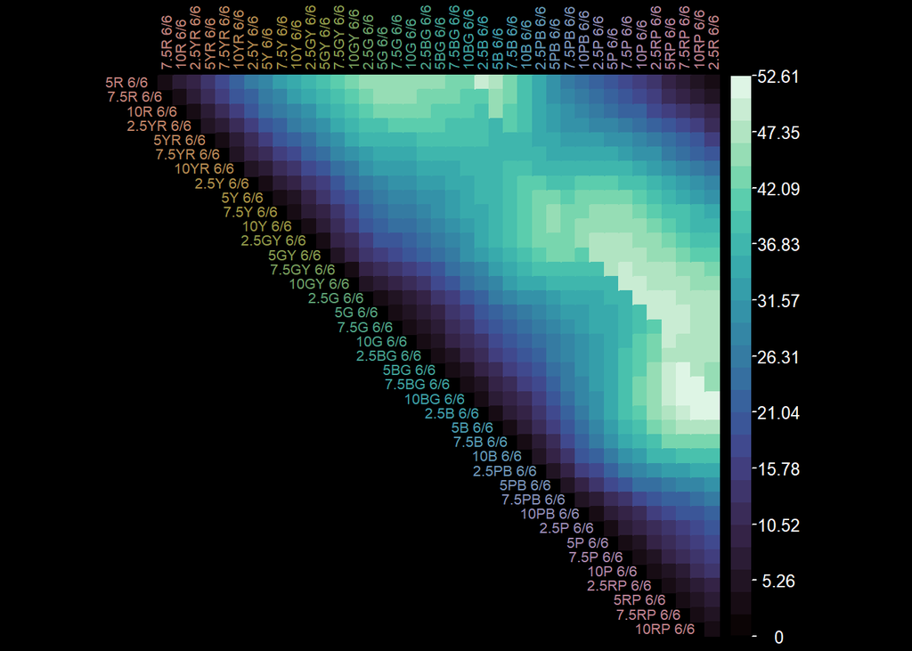

```r
x <- x[x$hue != 'N', ]

d <- farver::compare_colour(
  from = x[, c('L', 'A', 'B')],
  to = x[, c('L', 'A', 'B')],
  from_space = 'lab',
  method = 'CIE2000'
)

dimnames(d) <- list(x$m, x$m)

par(fg = 'white', bg = 'black')
corrplot(
    d,
    col = mako(25),
    is.corr = FALSE,
    col.lim = range(d),
    method = "color",
    order = "original",
    type = "upper",
    diag = FALSE,
    tl.cex = 0.66,
    tl.col = x$col,
    # tl.col = 'white',
    mar = c(0.1, 0, 0, 0.8),
    # addgrid = TRUE,
  )
```

## 2.9 Example 2

```r
data(munsell)
x1 <- subset(munsell, subset = value %in% 2:6 & chroma %in% c(0, 2:6) & hue != 'N')
x2 <- subset(munsell, subset = hue == 'N')


cols1 <- paste0(x1$hue, ' ', x1$value, '/', x1$chroma)
cols2 <- paste0(x2$hue, ' ', x2$value, '/', x2$chroma)

z <- expand.grid(colors = cols1, neutral = cols2)

d <- colorContrast(z$neutral, z$colors)

# extract hue
.m1 <- parseMunsell(d$m1, convertColors = FALSE)
.m2 <- parseMunsell(d$m2, convertColors = FALSE)

d$.hue1 <- factor(.m1$hue, levels = huePosition(returnHues = TRUE, includeNeutral = TRUE))
d$.hue2 <- factor(.m2$hue, levels = huePosition(returnHues = TRUE, includeNeutral = TRUE))

d$.value1 <- .m1$value
d$.value2 <- .m2$value
```

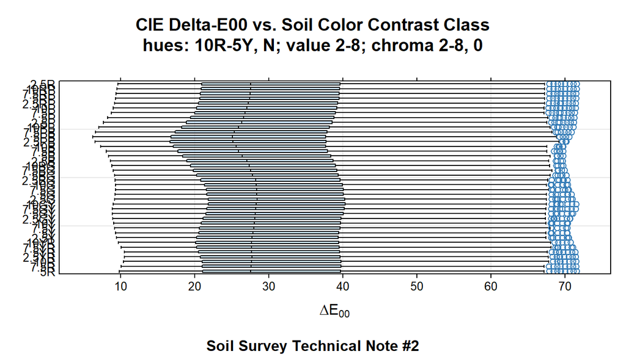

```r
bwplot(.hue2 ~ dE00, data = d,
       par.settings = tactile.theme(),
       xlab = expression(Delta*E['00']),
       main = 'CIE Delta-E00 vs. Soil Color Contrast Class\nhues: 10R-5Y, N; value 2-8; chroma 2-8, 0',
       sub = 'Soil Survey Technical Note #2',
       scales = list(x = list(tick.number = 10)),
       panel = function(...) {
         panel.grid(h = 3, v = -1)
         panel.bwplot(...)
       })
```

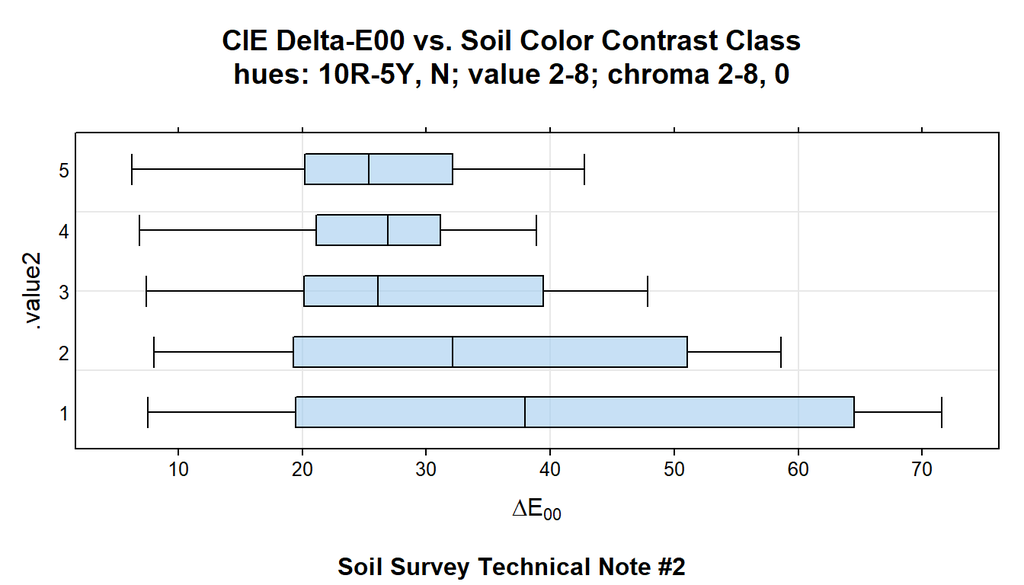

```r
bwplot(.value2  ~ dE00, data = d,
       par.settings = tactile.theme(),
       xlab = expression(Delta*E['00']),
       main = 'CIE Delta-E00 vs. Soil Color Contrast Class\nhues: 10R-5Y, N; value 2-8; chroma 2-8, 0',
       sub = 'Soil Survey Technical Note #2',
       scales = list(x = list(tick.number = 10)),
       panel = function(...) {
         panel.grid(h = 3, v = -1)
         panel.bwplot(...)
       })
```

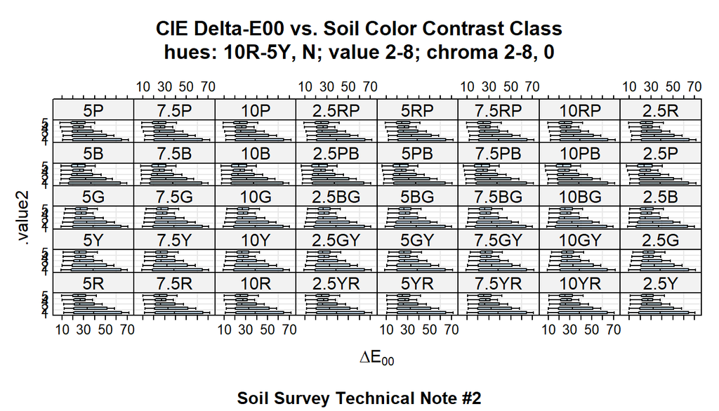

```r
bwplot(.value2  ~ dE00 | .hue2, data = d,
       par.settings = tactile.theme(),
       xlab = expression(Delta*E['00']),
       main = 'CIE Delta-E00 vs. Soil Color Contrast Class\nhues: 10R-5Y, N; value 2-8; chroma 2-8, 0',
       sub = 'Soil Survey Technical Note #2',
       scales = list(x = list(tick.number = 10)),
       panel = function(...) {
         panel.grid(h = 3, v = -1)
         panel.bwplot(...)
       })
```

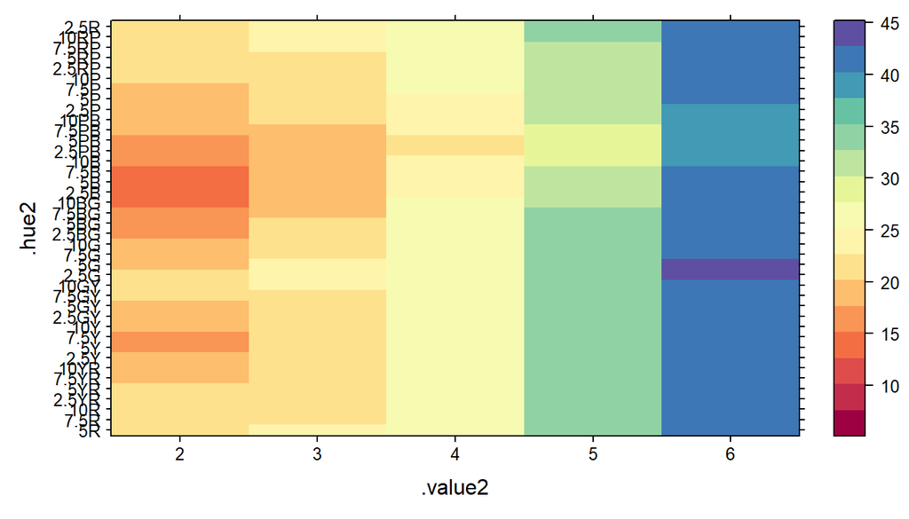

```r
levelplot(
  dE00 ~ .value2 * .hue2, data = d,
  subset = .value1 == 2,
  par.settings = tactile.theme()

)
```